# Loan Data Exploration

## Preliminary Wrangling

> This data set contains 113,937 loans with 81 variables on each loan, including loan amount, borrower rate (or interest rate), current loan status, borrower income.

```python
# import all packages and set plots to be embedded inline
import numpy as np
import pandas as pd
import matplotlib.pyplot as plt
import seaborn as sb

df = pd.read_csv('prosperLoanData.csv')
%matplotlib inline
```

> Load in your dataset and describe its properties through the questions below. Try and motivate your exploration goals through this section.

```python
print(df.shape)
```

```
(113937, 81)
```

```python
df.head()
```

|  | ListingKey | ListingNumber | ListingCreationDate | CreditGrade | Term | LoanStatus | ClosedDate | BorrowerAPR | BorrowerRate | LenderYield | ... | LP_ServiceFees | LP_CollectionFees | LP_GrossPrincipalLoss | LP_NetPrincipalLoss | LP_NonPrincipalRecoverypayments | PercentFunded | Recommendations | InvestmentFromFriendsCount | InvestmentFromFriendsAmount | Investors |
| --- | --- | --- | --- | --- | --- | --- | --- | --- | --- | --- | --- | --- | --- | --- | --- | --- | --- | --- | --- | --- | --- |
| 0 | 1021339766868145413AB3B | 193129 | 2007-08-26 19:09:29.263000000 | C | 36 | Completed | 2009-08-14 00:00:00 | 0.16516 | 0.1580 | 0.1380 | ... | -133.18 | 0.0 | 0.0 | 0.0 | 0.0 | 1.0 | 0 | 0 | 0.0 | 258 |
| 1 | 10273602499503308B223C1 | 1209647 | 2014-02-27 08:28:07.900000000 | NaN | 36 | Current | NaN | 0.12016 | 0.0920 | 0.0820 | ... | 0.00 | 0.0 | 0.0 | 0.0 | 0.0 | 1.0 | 0 | 0 | 0.0 | 1 |
| 2 | 0EE9337825851032864889A | 81716 | 2007-01-05 15:00:47.090000000 | HR | 36 | Completed | 2009-12-17 00:00:00 | 0.28269 | 0.2750 | 0.2400 | ... | -24.20 | 0.0 | 0.0 | 0.0 | 0.0 | 1.0 | 0 | 0 | 0.0 | 41 |
| 3 | 0EF5356002482715299901A | 658116 | 2012-10-22 11:02:35.010000000 | NaN | 36 | Current | NaN | 0.12528 | 0.0974 | 0.0874 | ... | -108.01 | 0.0 | 0.0 | 0.0 | 0.0 | 1.0 | 0 | 0 | 0.0 | 158 |
| 4 | 0F023589499656230C5E3E2 | 909464 | 2013-09-14 18:38:39.097000000 | NaN | 36 | Current | NaN | 0.24614 | 0.2085 | 0.1985 | ... | -60.27 | 0.0 | 0.0 | 0.0 | 0.0 | 1.0 | 0 | 0 | 0.0 | 20 |

5 rows × 81 columns

```python
df.describe()
```

|  | ListingNumber | Term | BorrowerAPR | BorrowerRate | LenderYield | EstimatedEffectiveYield | EstimatedLoss | EstimatedReturn | ProsperRating (numeric) | ProsperScore | ... | LP_ServiceFees | LP_CollectionFees | LP_GrossPrincipalLoss | LP_NetPrincipalLoss | LP_NonPrincipalRecoverypayments | PercentFunded | Recommendations | InvestmentFromFriendsCount | InvestmentFromFriendsAmount | Investors |
| --- | --- | --- | --- | --- | --- | --- | --- | --- | --- | --- | --- | --- | --- | --- | --- | --- | --- | --- | --- | --- | --- |
| count | 1.139370e+05 | 113937.000000 | 113912.000000 | 113937.000000 | 113937.000000 | 84853.000000 | 84853.000000 | 84853.000000 | 84853.000000 | 84853.000000 | ... | 113937.000000 | 113937.000000 | 113937.000000 | 113937.000000 | 113937.000000 | 113937.000000 | 113937.000000 | 113937.000000 | 113937.000000 | 113937.000000 |
| mean | 6.278857e+05 | 40.830248 | 0.218828 | 0.192764 | 0.182701 | 0.168661 | 0.080306 | 0.096068 | 4.072243 | 5.950067 | ... | -54.725641 | -14.242698 | 700.446342 | 681.420499 | 25.142686 | 0.998584 | 0.048027 | 0.023460 | 16.550751 | 80.475228 |
| std | 3.280762e+05 | 10.436212 | 0.080364 | 0.074818 | 0.074516 | 0.068467 | 0.046764 | 0.030403 | 1.673227 | 2.376501 | ... | 60.675425 | 109.232758 | 2388.513831 | 2357.167068 | 275.657937 | 0.017919 | 0.332353 | 0.232412 | 294.545422 | 103.239020 |
| min | 4.000000e+00 | 12.000000 | 0.006530 | 0.000000 | -0.010000 | -0.182700 | 0.004900 | -0.182700 | 1.000000 | 1.000000 | ... | -664.870000 | -9274.750000 | -94.200000 | -954.550000 | 0.000000 | 0.700000 | 0.000000 | 0.000000 | 0.000000 | 1.000000 |
| 25% | 4.009190e+05 | 36.000000 | 0.156290 | 0.134000 | 0.124200 | 0.115670 | 0.042400 | 0.074080 | 3.000000 | 4.000000 | ... | -73.180000 | 0.000000 | 0.000000 | 0.000000 | 0.000000 | 1.000000 | 0.000000 | 0.000000 | 0.000000 | 2.000000 |
| 50% | 6.005540e+05 | 36.000000 | 0.209760 | 0.184000 | 0.173000 | 0.161500 | 0.072400 | 0.091700 | 4.000000 | 6.000000 | ... | -34.440000 | 0.000000 | 0.000000 | 0.000000 | 0.000000 | 1.000000 | 0.000000 | 0.000000 | 0.000000 | 44.000000 |
| 75% | 8.926340e+05 | 36.000000 | 0.283810 | 0.250000 | 0.240000 | 0.224300 | 0.112000 | 0.116600 | 5.000000 | 8.000000 | ... | -13.920000 | 0.000000 | 0.000000 | 0.000000 | 0.000000 | 1.000000 | 0.000000 | 0.000000 | 0.000000 | 115.000000 |
| max | 1.255725e+06 | 60.000000 | 0.512290 | 0.497500 | 0.492500 | 0.319900 | 0.366000 | 0.283700 | 7.000000 | 11.000000 | ... | 32.060000 | 0.000000 | 25000.000000 | 25000.000000 | 21117.900000 | 1.012500 | 39.000000 | 33.000000 | 25000.000000 | 1189.000000 |

8 rows × 61 columns

```python
# I will only use the year the listing was created in my analysis
df['year'] = pd.DatetimeIndex(df['ListingCreationDate']).year
df['year']
```

```
0         2007
1         2014
2         2007
3         2012
4         2013
          ...
113932    2013
113933    2011
113934    2013
113935    2011
113936    2014
Name: year, Length: 113937, dtype: int64
```

```python
df['EmploymentStatus'].value_counts()
```

```
Employed         67322
Full-time        26355
Self-employed     6134
Not available     5347
Other             3806
Part-time         1088
Not employed       835
Retired            795
Name: EmploymentStatus, dtype: int64
```

I will set 'other' to NaN values.

```python
df['EmploymentStatus'].replace('Other', np.NaN, inplace = True);
df['EmploymentStatus'].value_counts()
```

```
Employed         67322
Full-time        26355
Self-employed     6134
Not available     5347
Part-time         1088
Not employed       835
Retired            795
Name: EmploymentStatus, dtype: int64
```

### What is the structure of your dataset?

> 113937 rows, 81 columns

### What is/are the main feature(s) of interest in your dataset?

> LoanOriginalAmount, BorrowerRate

### What features in the dataset do you think will help support your investigation into your feature(s) of interest?

> Term, EmploymentStatus, IsBorrowerHomeowner, AvailableBankcardCredit, TotalProsperLoans, year

## Univariate Exploration

### What is the average length of the loan in the dataset?

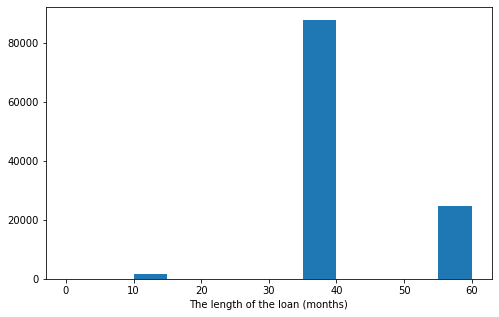

```python
# start with a standard-scaled plot
binsize = 5
bins = np.arange(0, df['Term'].max()+binsize, binsize)

plt.figure(figsize=[8, 5])
plt.hist(data = df, x = 'Term', bins = bins)
plt.xlabel('The length of the loan (months)')
plt.show()
```

Looking at the distribution of the Term of the loan, it's quite obvious that there are only 3 unique values. Lets invistigate this insight further.

```python
df['Term'].value_counts()
```

```
36    87778
60    24545
12     1614
Name: Term, dtype: int64
```

There are only 3 values for the length of the loan, a year (12 months), 3 years (36 months) or 5 years (60 months). Most of the debts in this dataset are 3 years long debts.

### What is the average Borrower's interest rate in the dataset?

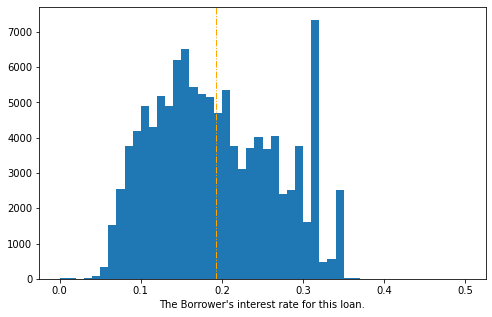

```python
binsize = 0.01
bins = np.arange(0, df['BorrowerRate'].max()+binsize, binsize)

plt.figure(figsize=[8, 5])
plt.hist(data = df, x = 'BorrowerRate', bins = bins)
plt.xlabel("The Borrower's interest rate for this loan.")
plt.axvline(df['BorrowerRate'].mean(), color='orange', linestyle='-.', linewidth=1)
plt.show()
```

In the case of Borrowers's interest rate, the distribution looks roughly normal but with an isolated peak at nearly 0.32. The bulk of the interest rate is between 0.12 and 0.2 and the bulk other than the peak looks right skewed.

### Are most of the borrowers employed? Do they own a house?

```python
default_color = sb.color_palette()[0]
```

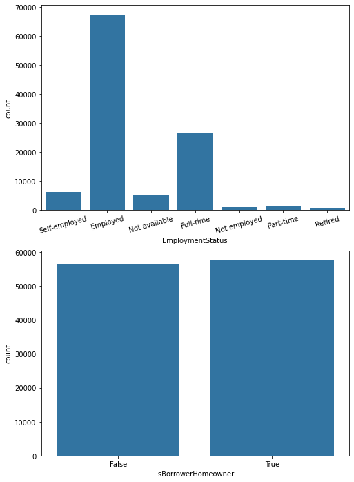

```python
fig, ax = plt.subplots(nrows=2, figsize = [8,12])

default_color = sb.color_palette()[0]
chart = sb.countplot(data = df, x = 'EmploymentStatus', color = default_color, ax = ax[0])
chart.set_xticklabels(chart.get_xticklabels(), rotation=15)
sb.countplot(data = df, x = 'IsBorrowerHomeowner', color = default_color, ax = ax[1])


plt.show()
```

Looking at 'EmploymentStatus' column, it stands out that the vast majority of the borrowers in our dataset are employed. Some of them are full-time workers and self-employed. It's also obvious that a very small minority of the borrowers are retired, not employed or part-time workers.

Interestingly, there is no trend seen in the borrowers when it comes to homeowning, nearly half of the borrowers don't own a house.

### What is the distribution of the total available credit via bank card at the time the credit profile was pulled look like?

```python
df['AvailableBankcardCredit'].describe()
```

```
count    106393.000000
mean      11210.225447
std       19818.361309
min           0.000000
25%         880.000000
50%        4100.000000
75%       13180.000000
max      646285.000000
Name: AvailableBankcardCredit, dtype: float64
```

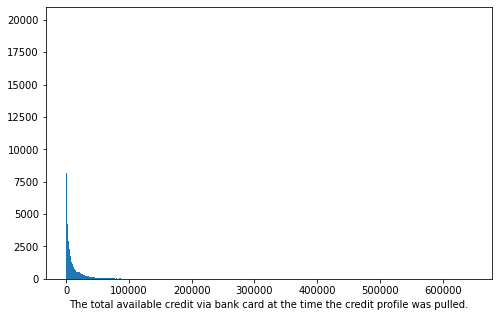

```python
binsize = 500
bins = np.arange(0, df['AvailableBankcardCredit'].max()+binsize, binsize)

plt.figure(figsize=[8, 5])
plt.hist(data = df, x = 'AvailableBankcardCredit', bins = bins)
plt.xlabel("The total available credit via bank card at the time the credit profile was pulled.")
plt.show()
```

there's a long tail in the distribution, so let's put it on a log scale instead

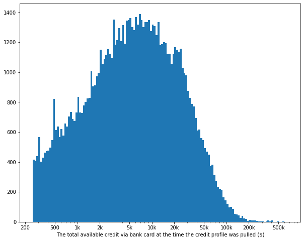

```python
log_binsize = 0.025
bins = 10 ** np.arange(2.4, np.log10(df['AvailableBankcardCredit'].max())+log_binsize, log_binsize)

plt.figure(figsize=[10, 8])
plt.hist(data = df, x = 'AvailableBankcardCredit', bins = bins)
plt.xscale('log')
plt.xticks([200,500, 1e3, 2e3, 5e3, 1e4, 2e4, 5e4, 1e5, 2e5, 5e5], [200, 500, '1k', '2k', '5k', '10k', '20k', '50k', '100k', '200k', '500k'])
plt.xlabel("The total available credit via bank card at the time the credit profile was pulled ($)")
plt.show()
```

AvailableBankcardCredit has a long-tailed distribution, with a lot of borrowers on the low price end, and few on the high price end. When plotted on a log-scale, the AvailableBankcardCredit distribution looks roughly right skewed, with most of the BankCredits lower than 50k.

### Was this the borrower's first listing?

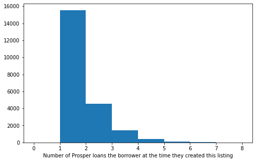

```python
binsize = 1
bins = np.arange(0, df['TotalProsperLoans'].max()+binsize, binsize)

plt.figure(figsize=[8, 5])
plt.hist(data = df, x = 'TotalProsperLoans', bins = bins)
plt.xlabel("Number of Prosper loans the borrower at the time they created this listing")
plt.show()
```

```python
df['TotalProsperLoans'].value_counts(dropna = False)
```

```
NaN    91852
1.0    15538
2.0     4540
3.0     1447
4.0      417
5.0      104
6.0       29
7.0        8
8.0        1
0.0        1
Name: TotalProsperLoans, dtype: int64
```

Again, the distribution is right skewed with the vast majority of borrowers had no prior listing.

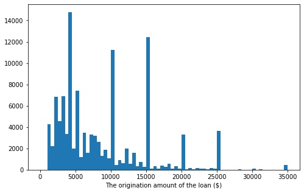

```python
binsize = 500
bins = np.arange(0, df['LoanOriginalAmount'].max()+binsize, binsize)

plt.figure(figsize=[8, 5])
plt.hist(data = df, x = 'LoanOriginalAmount', bins = bins)
plt.xlabel("The origination amount of the loan ($)")
plt.show()
```

```python
df['LoanOriginalAmount'].value_counts()
```

```
4000     14333
15000    12407
10000    11106
5000      6990
2000      6067
         ...
7765         1
5652         1
9746         1
15889        1
12282        1
Name: LoanOriginalAmount, Length: 2468, dtype: int64
```

The distribution of the amount of the loan is multimodal. It peaks at 4000, 10k and 15k.

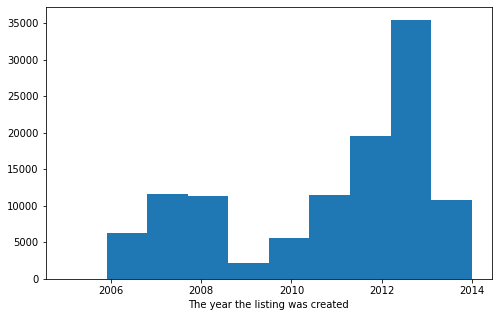

```python
binsize = 1
bins = np.arange(2000, df['year'].max()+binsize, binsize)

plt.figure(figsize=[8, 5])
plt.hist(data = df, x = 'year')
plt.xlabel("The year the listing was created")
plt.show()
```

- The distribution looks rougly bimodal. Most of the listings were created between 2011 and 2014 with a peak number of listings in 2013.
- after 2008 there was a radical decline in the number of loans for nearly 2 years. This is probably because of the Financial crisis.

### Discuss the distribution(s) of your variable(s) of interest. Were there any unusual points? Did you need to perform any transformations?

The AvailableBankcardCredit variable took on a large range of values, so I looked at the data using a log transform. Under the transformation, the data looked rightskewed, with a peak at roughly 7.5k usd.

### Of the features you investigated, were there any unusual distributions? Did you perform any operations on the data to tidy, adjust, or change the form of the data? If so, why did you do this?

- I chose to only invistigate the year the debt was listed so i extracted that of the ListingCreationDate column.
- Replaced the "other" value in the EmploymentStatus column with NaN values. It wouldn't be usefull in our case.

In the graphs above, I looked at the distributions of most of the numeric variables I intend to use in my analysis. I also looked at 2 categorical variables.

- There are only 3 values that the length of the debt can take. One, Three or Five years. Most of the loans span over 3 years.
- The distribution of the borrower's interest rate is bimodal.
- Most of the borrowers are employed and half of them own a house.
- The distribution of the Available card credit is right skewed. The majority between 2k and 50k with some extreme values near 500k.
- This is the first listing for the vast majority of the borrowers in the dataset.
- The distribution of the amount of the loan is multimodal. It peaks at 4000, 10k and 15k.
- The data is relatively new. Most of it collected between 2011 and 2014.
- After 2008 there was a radical decline in the number of loans for nearly 2 years. This is probably because of the Financial crisis.

## Bivariate Exploration

To start off with, I want to look at the pairwise correlations present between features in the data.

```python
numeric_vars = ['year', 'Term', 'BorrowerRate', 'AvailableBankcardCredit', 'TotalProsperLoans', 'LoanOriginalAmount']
categoric_vars = ['IsBorrowerHomeowner', 'EmploymentStatus']
```

### Heatmap

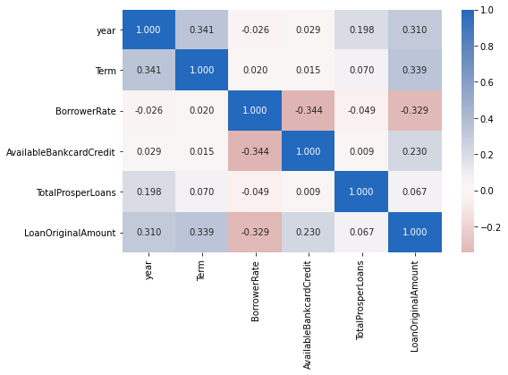

```python
plt.figure(figsize = [8, 5])
sb.heatmap(df[numeric_vars].corr(), annot = True, fmt = '.3f',
           cmap = 'vlag_r', center = 0)
plt.show()
```

From the heatmap above, there is no strong **linear** relation between any of our numeric variables. However, there is a weak positive linear relationship between the original amount of the loan and the term of the loan. There's also a weak negative relationship between the available bank card credit and the borrower rate which makes sense.

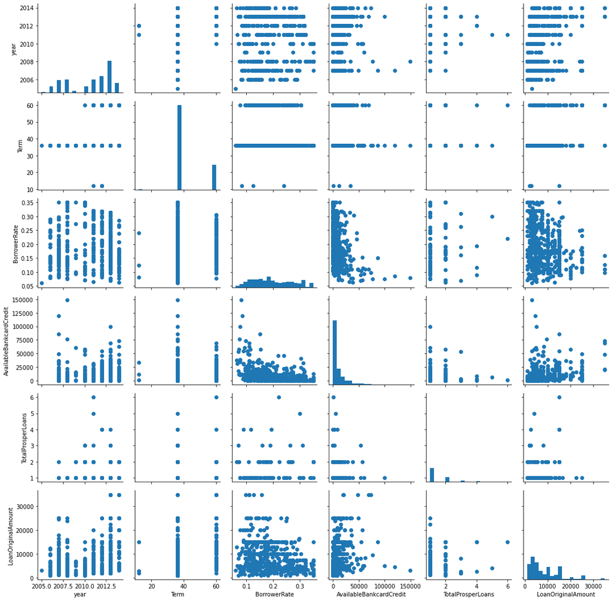

```python
# plot matrix: sample 500 diamonds so that plots are clearer and
# they render faster
samples = np.random.choice(df.shape[0], 500, replace = False)
df_samp = df.loc[samples,:]

g = sb.PairGrid(data = df_samp, vars = numeric_vars)
g = g.map_diag(plt.hist, bins = 20);
g.map_offdiag(plt.scatter)
```

Let's move on to looking at how Available Bank Card Credit, Loan original amount and Borrower rate correlate with the categorical variables.

### Term vs Loan Original Amount

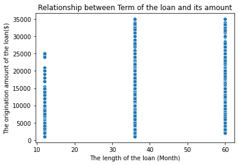

```python
# I will seprate this figure to use it later
sb.scatterplot(data = df, x = 'Term', y = 'LoanOriginalAmount');
plt.ylabel('The origination amount of the loan($)')
plt.xlabel('The length of the loan (Month)')
plt.title('Relationship between Term of the loan and its amount');
```

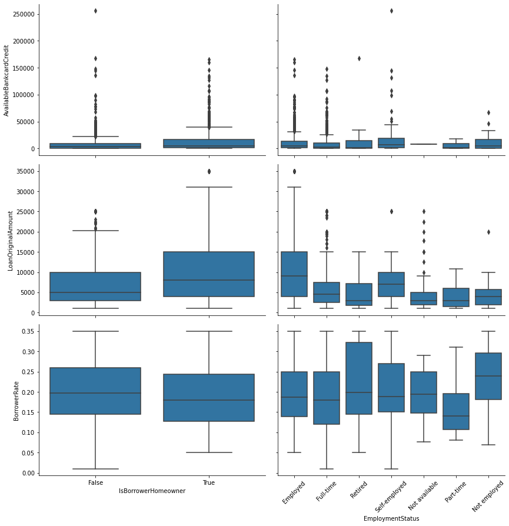

```python
# plot matrix of numeric features against categorical features.
# can use a larger sample since there are fewer plots and they're simpler in nature.

samples = np.random.choice(df.shape[0], 2000, replace = False)
df_samp = df.loc[samples,:]

def boxgrid(x, y, **kwargs):
    default_color = sb.color_palette()[0]
    sb.boxplot(x, y, color = default_color)

plt.figure(figsize = [20, 20])
g = sb.PairGrid(data = df_samp, y_vars = ['AvailableBankcardCredit', 'LoanOriginalAmount', 'BorrowerRate'], x_vars = categoric_vars,
                size = 4, aspect = 1.5)
g.map(boxgrid)
plt.xticks(rotation=45)
plt.show();
```

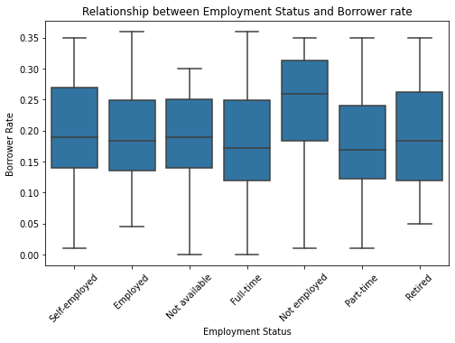

```python
plt.figure(figsize = [8, 5])
sb.boxplot(data = df, x = 'EmploymentStatus', y = 'BorrowerRate', color = default_color)
plt.xticks(rotation=45)
plt.xlabel('Employment Status')
plt.ylabel('Borrower Rate')
plt.title('Relationship between Employment Status and Borrower rate');
plt.show();
```

The figure shows that the unemployed had the highest borrower rates of all other employment status with an average of around 0.25.

- Interestingly, Homeowners chose slighly less borrower rates on average. Moreover, the amount of their loans were generally larger but people who don't own a house had more outliers. Homeowners had more available bank credit on average as expected.
- Looking at the Employment status figures, it immediately stands out that the unemployed had more borrower rates on average (nearly 0.25). People who are employed had the largest loans on average.

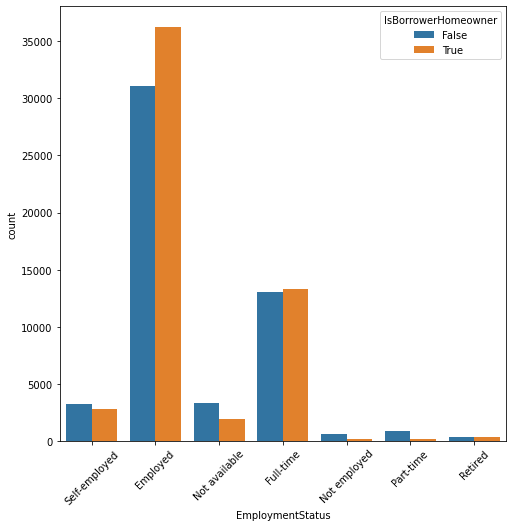

```python
# since there's only one subplots to create, using the full data should be fine.
plt.figure(figsize = [8, 8])

sb.countplot(data = df, x = 'EmploymentStatus', hue = 'IsBorrowerHomeowner')
plt.xticks(rotation=45)
plt.show()
```

- It stands out that although most employed borrowers were homeowners as expected, the number of non-homeowners is also very large which indicates that the corelation between those 2 variables is not that strong.
- The full-time workers figure indicates that nearly half of them owned houses which further assures that there is no that much interaction between the 2 variables.
- However, most of the part-time workers didn't own a house.

With the preliminary look at bivariate relationships out of the way, I want to dig into some of the relationships more. First, I want to see how AvailableBankcardCredit and LoanOriginalAmount are related to one another for all of the data, and to plot AvailableBankcardCredit on a log scale.

```python
df['LoanOriginalAmount'].describe()
```

```
count    113937.00000
mean       8337.01385
std        6245.80058
min        1000.00000
25%        4000.00000
50%        6500.00000
75%       12000.00000
max       35000.00000
Name: LoanOriginalAmount, dtype: float64
```

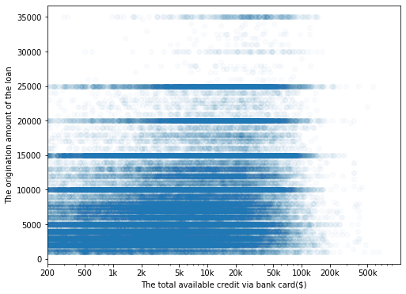

```python
# scatter plot of AvailableBankcardCredit vs. LoanOriginalAmount, with log transform on AvailableBankcardCredit axis

plt.figure(figsize = [8, 6])
plt.scatter(data = df, y = 'LoanOriginalAmount', x = 'AvailableBankcardCredit', alpha = 1/40)
plt.ylabel('The origination amount of the loan')
plt.xscale('log')
plt.xticks([200,500, 1e3, 2e3, 5e3, 1e4, 2e4, 5e4, 1e5, 2e5, 5e5], [200, 500, '1k', '2k', '5k', '10k', '20k', '50k', '100k', '200k', '500k'])
plt.xlabel('The total available credit via bank card($)')
plt.show()
```

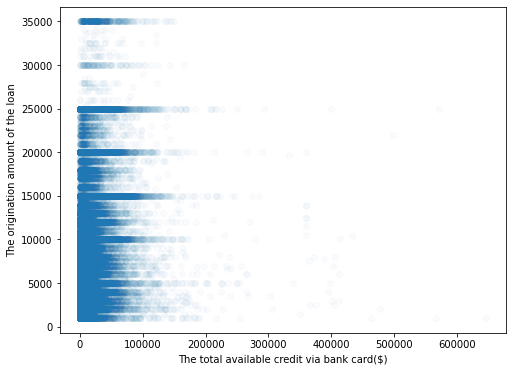

```python
plt.figure(figsize = [8, 6])
plt.scatter(data = df, y = 'LoanOriginalAmount', x = 'AvailableBankcardCredit', alpha = 1/40)
plt.ylabel('The origination amount of the loan')
plt.xlabel('The total available credit via bank card($)')
plt.show()
```

The plots don't give much information as there is no obvious trend to be observed. We can only see that there exist more listings with an loan amount of 5k, 10k, 15k, 20k, 25k more 35k than other values. However, it doesn't appear to be a relationship between the two variables because the available credit via bank card for 25k loans takes a similar range for those of value 5k but with a smaller number of loans listed (which is expected).

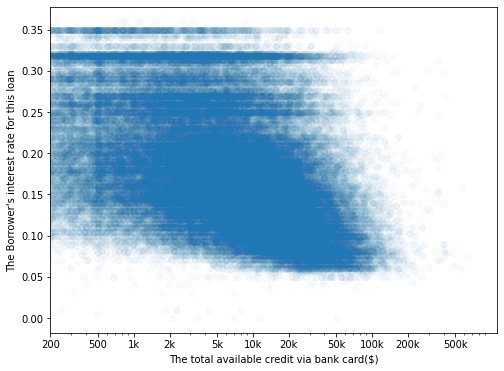

```python
# scatter plot of AvailableBankcardCredit vs. BorrowerRate, with log transform on AvailableBankcardCredit axis

plt.figure(figsize = [8, 6])
plt.scatter(data = df, y = 'BorrowerRate', x = 'AvailableBankcardCredit', alpha = 1/40)
plt.ylabel("The Borrower's interest rate for this loan")
plt.xscale('log')
plt.xticks([200,500, 1e3, 2e3, 5e3, 1e4, 2e4, 5e4, 1e5, 2e5, 5e5], [200, 500, '1k', '2k', '5k', '10k', '20k', '50k', '100k', '200k', '500k'])
plt.xlabel('The total available credit via bank card($)')
plt.show()
```

It stands out that the more the available credit, the less interest rate. People with more than 50k $ is their bank acount nearly always got an interest rate less than 0.25. People with available bank credit less than 5k nearly always got an interest rate of more than 0.10.

### Talk about some of the relationships you observed in this part of the investigation. How did the feature(s) of interest vary with other features in the dataset?

> - Homeowners chose slighly less borrower rates on average. Moreover, the amount of their loans were generally larger but people who don't own a house had more outliers. Homeowners had more available bank credit on average as expected.
> - the more the available credit, the less interest rate. People with more than 50k is their bank acount nearly always got an interest rate less than 0.25. People with available bank credit less than 5k nearly always got an interest rate of more than 0.10.

### Did you observe any interesting relationships between the other features (not the main feature(s) of interest)?

> - The unemployed had more borrower rates on average (nearly 0.25). People who are employed had the largest loans on average.
> - The shorter term loans was typically smaller (original amount), and people who chose short term loans had no prior listings or just one listing. Most of the short term debts were placed between 2011 and 2014.

## Multivariate Exploration

The main thing I want to explore in this part of the analysis is how the two categorical measures play into the relationship between LoanOriginalAmount and BorrowerRate.

```python
def hist2dgrid(x, y, **kwargs):
    palette = kwargs.pop('color')
    plt.hist2d(x, y, cmap = palette, cmin = 0.5)
```

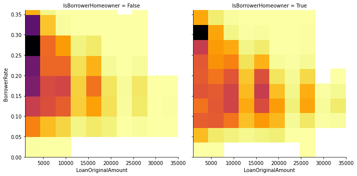

```python
# create faceted heat maps on levels of the IsBorrowerHomeowner variable
g = sb.FacetGrid(data = df, col = 'IsBorrowerHomeowner', size = 5)
g.map(hist2dgrid, 'LoanOriginalAmount', 'BorrowerRate', color = 'inferno_r')
g.set_xlabels('LoanOriginalAmount')
g.set_ylabels('BorrowerRate')

plt.show()
```

Non-homeowners tended to get the vast majority of the small loans with high borrower rates. Their small listings took a large range of borrower rates with most of them from 0.15 to 0.35.

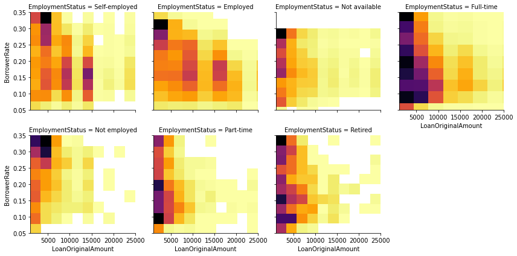

```python
# create faceted heat maps on levels of the IsBorrowerHomeowner variable
g = sb.FacetGrid(data = df, col = 'EmploymentStatus',col_wrap = 4 ,size = 3)
g.map(hist2dgrid, 'LoanOriginalAmount', 'BorrowerRate', color = 'inferno_r')
g.set_xlabels('LoanOriginalAmount')
g.set_ylabels('BorrowerRate')

plt.show()
```

- Interestingly, the unemployed mostly chose loans with a very high borrower rates with most of their listings having borrower rates of around 0.3 to 0.35 but with an amount of less than 10k most of the times.
- People who chose the 'Not available' option when it comes to employment status didn't get any listings with borrower rate more than 0.3 although they had a large number of listings with borrower rate of exactly 0.3 with a loan amount of less than 5k.
- Part-time workers didn't get as much high borrower rate loans as other people of other employment status. A very large amount of their loans had a borrowr rate of around 0.2.

### Talk about some of the relationships you observed in this part of the investigation. Were there features that strengthened each other in terms of looking at your feature(s) of interest?

> - Non-homeowners tended to get the vast majority of the small loans with high borrower rates. Their small listings took a large range of borrower rates with most of them from 0.15 to 0.35.
> - Interestingly, the unemployed mostly chose loans with a very high borrower rates with most of their listings having borrower rates of around 0.3 to 0.35 but with an amount of less than 10k most of the times.

### Were there any interesting or surprising interactions between features?

> - People who chose the 'Not available' option when it comes to employment status didn't get any listings with borrower rate more than 0.3 although they had a large number of listings with borrower rate of exactly 0.3 with a loan amount of less than 5k.
> - Part-time workers didn't get as much high borrower rate loans as other people of other employment status. A very large amount of their loans had a borrowr rate of around 0.2.